# Valeurs Extrêmes

Marlène Chevalier

02 février 2020

# Sujet : niveaux maximum de la mer dans la région de Port Pirie (Australie du Sud)

Il s’agit d’étudier les valeurs extrêmes des niveaux annuels de la mer qui ont été enregistrés dans la région de Port Pirie, au nord d’Adélaïde, en Australie du Sud, au cours de la période 1923-1987.

source : *data(portpirie)*

Nous cherchons à obtenir une estimation du niveau maximal de la mer susceptible de se produire dans cette région au cours des 100 et 1000 prochaines années. On supposera que le modèle est constant sur la période d’observation, de sorte que nous modélisons les données comme des observations indépendantes de la distribution du GEV : distribution des extrêmes généralisée.

# Description de la série

La série comprend 65 de niveaux maximum annuels de la mer (en mètre), relevés entre 1923 et 1987. Les niveaux sont compris entre 3.57m et 4.69m, avec une moyenne et une médiane proches (resp.3.98m et 3.96m), ce qui est confirmé par le boxplot reparti autour de la moyenne. Seules 3 valeurs sortent franchement du nuage de points : 4.69m en 1934, 4.55m en 1953 et 1981.

```
##       Year         SeaLevel
##  Min.   :1923   Min.   :3.570
##  1st Qu.:1939   1st Qu.:3.830
##  Median :1955   Median :3.960
##  Mean   :1955   Mean   :3.981
##  3rd Qu.:1971   3rd Qu.:4.110
##  Max.   :1987   Max.   :4.690
```

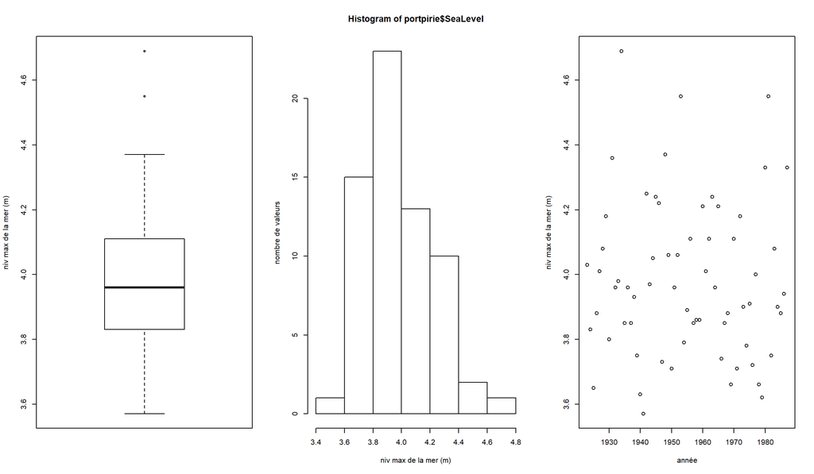

L’histogramme de la série est rapproché de densités théoriques sur le graphique ci-dessous : la loi gamma apparait comme la plus proche du comportement de la série des niveaux maximum de la mer à Port Pirie.

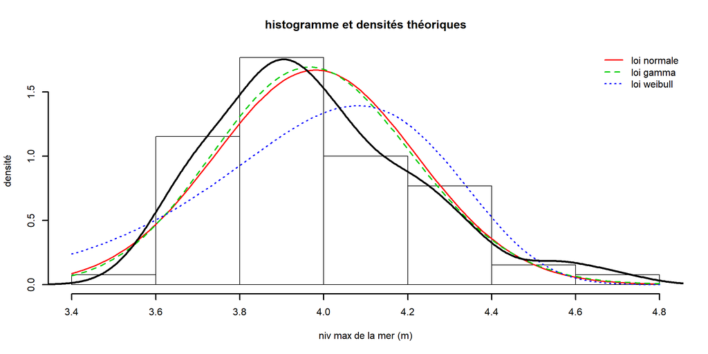

# Modélisation Generalized Extreme Value (GEV) : loi des maxima de la série

## Modèle GEV avec maximum de vraissemblance (MLE)

Les coefficients du modèle GEV, a (position), b (échelle), gamma (forme) sont estimés par maximum de vraissemblance (fonction *fevd*). A partir de la valeur estimée du paramètre forme, on déduira le domaine d’attraction des maxima (DMA), c’est à dire le domaine auquel appartient la loi caractérisant des niveaux maximum de la mer à Port Pirie.

```
##
## fevd(x = portpirie$SeaLevel, type = "GEV", method = "MLE")
##
## [1] "Estimation Method used: MLE"
##
##
##  Negative Log-Likelihood Value:  -4.339058
##
##
##  Estimated parameters:
##   location      scale      shape
##  3.8747499  0.1980440 -0.0501095
##
##  Standard Error Estimates:
##   location      scale      shape
## 0.02793224 0.02024798 0.09825416
##
##  Estimated parameter covariance matrix.
##               location         scale         shape
## location  0.0007802099  0.0001970436 -0.0010740750
## scale     0.0001970436  0.0004099808 -0.0007774225
## shape    -0.0010740750 -0.0007774225  0.0096538796
##
##  AIC = -2.678117
##
##  BIC = 3.845045
```

```
## fevd(x = portpirie$SeaLevel, type = "GEV", method = "MLE")
##
## [1] "Normal Approx."
##
##          95% lower CI   Estimate 95% upper CI
## location    3.8200037  3.8747499    3.9294960
## scale       0.1583586  0.1980440    0.2377293
## shape      -0.2426841 -0.0501095    0.1424651
```

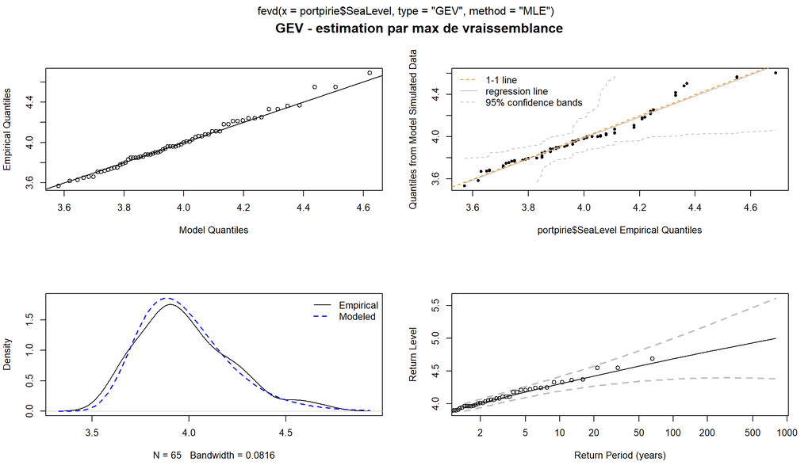

**Domaine d’attraction des valeurs extrêmes**

La valeur estimée de gamma (shape) est de -0.05 < 0. Elle caractérise le domaine d’attraction de Weibull. Cependant l’intervalle de confiance du paramètre gamma nous indique qu’il pourrait être positif (borne supérieure du CI >0). Nous testerons donc ci-après, le résultat de la modélisation pour gamma = 0 (domaine de Gumbel).  
Les graphiques montrent un bon ajustement de la loi des extrêmes au DMA de Weibull (points empiriques et modélisés proches, relation niveaux et période de retour proches des valeurs de la loi théorique).

**Point terminal**  
Le point terminal est la limite supérieure atteinte par le domaine d’attraction. Il s’agit de la valeur extrême qui ne pourra pas être dépassée : limite intrinsèque du phénomène observé (physique, technologique, physiologique…). Il s’obtient à partir des paramètres estimés: position - (échelle / forme).

Pour le domaine de Weibull, on calculera donc le point terminal pour illustrer la tendance des extrêmes à long terme . En effet, la loi de Weibull étant bornée supérieurement, l’estimation de niveaux de retour n’a pas de sens dans ce cas. Le point terminal est estimé ici à : 7.83 m

## Modèle Gumbel avec MLE

Nous testons ici l’appartenance du modèle des extrêmes au domaine de Gumbel, c’est à dire : est-ce que le paramètre de forme (gamma) peut être nul?

```
## fevd(x = portpirie$SeaLevel, type = "Gumbel", method = "MLE")
##
## [1] "Normal Approx."
##
##          95% lower CI  Estimate 95% upper CI
## location    3.8194765 3.8694436     3.919411
## scale       0.1579369 0.1948895     0.231842
```

```
## fevd(x = portpirie$SeaLevel, type = "Gumbel", method = "MLE")
##
## [1] "Normal Approx."
##
## [1] "100-year return level: 4.766"
##
## [1] "95% Confidence Interval: (4.5742, 4.9578)"
```

```
## fevd(x = portpirie$SeaLevel, type = "Gumbel", method = "MLE")
##
## [1] "Normal Approx."
##
## [1] "1000-year return level: 5.216"
##
## [1] "95% Confidence Interval: (4.9404, 5.4908)"
```

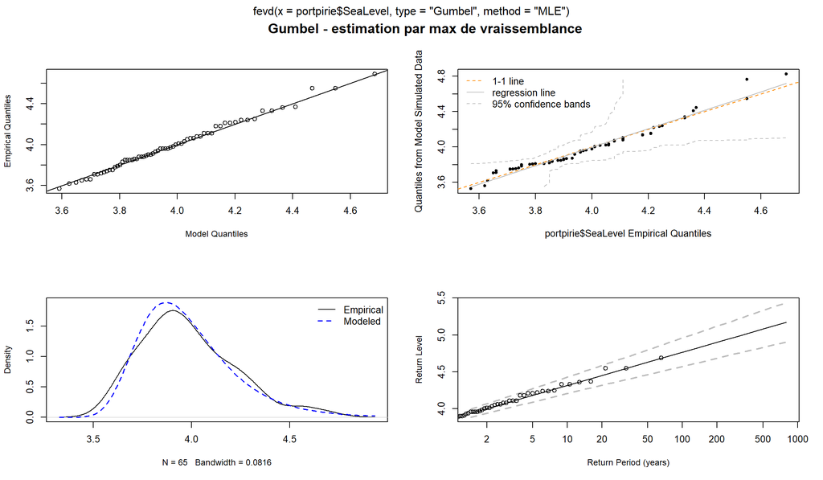

Les graphiques d’ajustement de la loi des niveau maximum vers une loi du domaine de Gumbel donnent de très bons résultats. L’hypothèse que le paramètre de forme, gamma, soit nul est donc possible. De plus, les intervalles de confiance des niveaux de retour à 100 ans et 1000 ans sont très resserrés autour de la valeur ponctuelle estimée, ce qui marque une précision forte de cette estimation.

**Niveaux de retour à 100 ans et 1000 ans**

Le niveau de retour à 100 ans est ici de 4.77 m et celui à 1000 ans de 5.22 m.

## Modèle GEV avec méthode des moments (PWM)

Ici, les coefficients du modèle GEV (position, echelle, forme) sont estimés par la méthode des moments.

```
## fevd(x = portpirie$SeaLevel, type = "GEV", method = "Lmoments")
## [1] "GEV  Fitted to  portpirie$SeaLevel  using L-moments estimation."
##    location       scale       shape
##  3.87317236  0.20326758 -0.05147713
```

```
## fevd(x = portpirie$SeaLevel, type = "GEV", method = "Lmoments")
##
## [1] "Parametric Bootstrap"
## 502  iterations
##
##                2.5%    Estimate     97.5%
## location  3.8231229  3.87317236 3.9292698
## scale     0.1644136  0.20326758 0.2415200
## shape    -0.2495330 -0.05147713 0.1124168
```

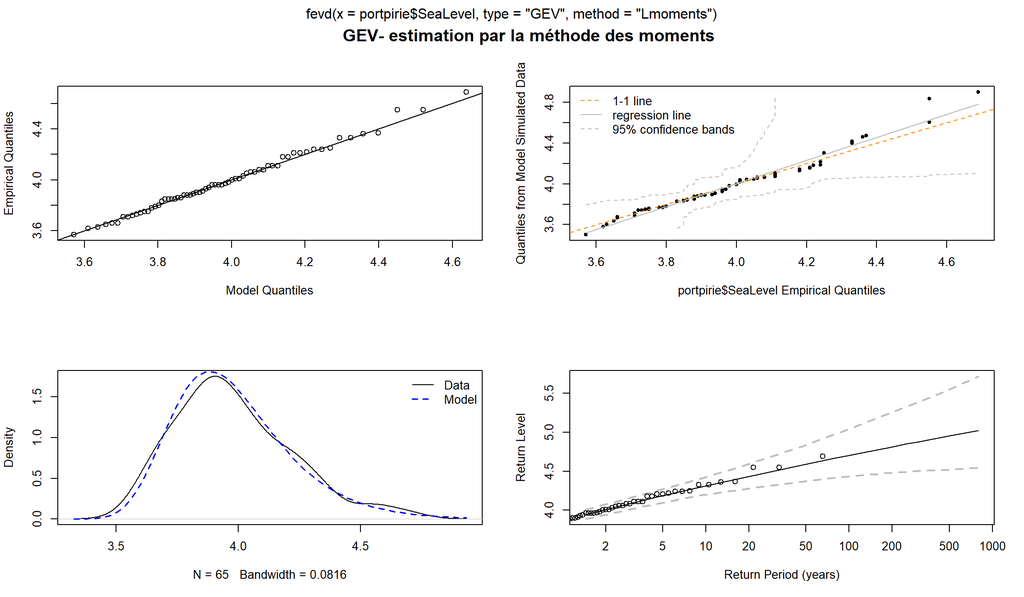

**Domaine d’attraction des valeurs extrêmes**

Les résultats sont quasi-identiques à ceux obtenus par l’estimation du maximum de vraissemblance. La valeur estimée de gamma (shape) est là aussi négative (=-0.05). Les graphiques montrent là aussi un bon ajustement de la loi des extrêmes au DMA de Weibull.

**Point terminal**

Le point terminal est dans ce cas de : 7.82 m

# Conclusion

| methode_d_estimation | estimation_param_forme | domaine | point_final | niv_retour_100_ans | niv_retour_1000_ans |
| --- | --- | --- | --- | --- | --- |
| GEV-MLE | -0.05 | Weibull | 7.83m | X | X |
| Gumble-MLE | 0 | Gumbel | X | 4.77m | 5.22m |
| GEV-Moment | -0.05 | Weibull | 7.82m | X | X |

Les résultats graphiques donnés par chaque méthode montrent de très bons ajustements. Il semble que ceux obtenus par Gumbel et l’estimation des paramètres par le maximum de vraissemblance soient légèrement meilleurs . De plus, envisager une borne limite pour le niveau de la mer (point terminal de Weibull) n’est pas intuitif. On retiendra donc le modèle de Gumbel.

**Modèle Gumbel avec estimation par maximum de vraissemblance**

**- Domaine = Gumbel**  
**- Estimation position = 3.87**  
**- Estimation echelle = 0.19**  
**- Estimation forme = 0**  
**- Niveau de retour à 100 ans = 4.8m**  
**- Niveau de retour à 1000 ans = 5.2m**